# Chapter 11 Naive Bayes

### Naive Bayes Classifier

Naive Bayes methods are a family of **supervised learning algorithms** that apply **Bayes’ theorem** under the “naive” assumption of **conditional independence** among features given the class variable.

Bayes’ theorem defines the relationship between a class variable $C$ and a dependent feature vector $X = (x_1, x_2, \ldots, x_n)$ as:

$$ P(C \mid X) = \frac{P(X \mid C) P(C)}{P(X)} $$

Under the **naive conditional independence** assumption that all features are independent given the class, i.e.,

$$ P(X \mid C) = \prod_{i=1}^{n} P(x_i \mid C), $$

the theorem simplifies to:

$$ P(C \mid X) \propto P(C) \prod_{i=1}^{n} P(x_i \mid C) $$

Since $P(X)$ is constant for all classes, classification can be performed using the **Maximum A Posteriori (MAP)** rule:

$$ \hat{C} = \arg\max_{C} P(C) \prod_{i=1}^{n} P(x_i \mid C) $$

Here, $P(C)$ is typically estimated as the **relative frequency** of class $C$ in the training set, while $P(x_i \mid C)$ depends on the assumed distribution of the features (e.g., Gaussian, Multinomial, or Bernoulli).  
The various **Naive Bayes classifiers** differ mainly in this distributional assumption. Despite its simplified assumptions, Naive Bayes often performs surprisingly well in many real-world applications such as **document classification** and **spam filtering**. It requires only a **small amount of training data** to estimate parameters effectively.

From a computational perspective, Naive Bayes is **extremely fast** because the class-conditional feature distributions are estimated **independently** as one-dimensional problems. This property helps mitigate the **curse of dimensionality**. However, while Naive Bayes is known to be a **good classifier**, it is also considered a **poor probability estimator**—the predicted probabilities (e.g., from `predict_proba`) should not be interpreted as well-calibrated likelihoods.

Assumptions of Naive Bayes

The Naive Bayes algorithm relies on several key assumptions about the features in the data:

1. **Feature Independence**  
   The features of the data are conditionally independent of each other, given the class label.
2. **Continuous Features are Normally Distributed**  
   If a feature is continuous, it is assumed to follow a normal (Gaussian) distribution within each class.
3. **Discrete Features have Multinomial Distributions**  
   If a feature is discrete, it is assumed to have a multinomial distribution within each class.
4. **Features are Equally Important**  
   All features are assumed to contribute equally to the prediction of the class label.
5. **No Missing Data**  
   The data should not contain any missing values, as Naive Bayes requires complete data for making predictions.

Types of Naive Bayes Models

There are three common types of Naive Bayes classifiers, each suited to different types of data:

1. **Gaussian Naive Bayes**  
   Used when features are continuous and assumed to follow a normal (Gaussian) distribution.  
   It estimates the mean and variance of each feature per class and computes likelihoods using the Gaussian probability density function.

The **Gaussian Naive Bayes (GNB)** model assumes that features are **continuous** and normally distributed within each class.

For a feature $x_i$ given class $C_k$, the likelihood is modeled by the Gaussian (normal) distribution:

$$ P(x_i \mid C_k) = \frac{1}{\sqrt{2\pi\sigma_{ki}^2}} \exp\left(-\frac{(x_i - \mu_{ki})^2}{2\sigma_{ki}^2}\right) $$

where:

- $\mu_{ki}$ = mean of feature $i$ for class $C_k$,
- $\sigma_{ki}^2$ = variance of feature $i$ for class $C_k$.

Each class thus has a mean and variance estimated for every feature.

Parameter Estimation

$$ \hat{\mu}_{ki} = \frac{1}{N_k} \sum_{x_j \in C_k} x_{ji}, \quad \hat{\sigma}_{ki}^2 = \frac{1}{N_k} \sum_{x_j \in C_k} (x_{ji} - \hat{\mu}_{ki})^2 $$

2. **Multinomial Naive Bayes**  
   Commonly used for **text classification** tasks where features represent word counts or frequencies.  
   It assumes that features follow a multinomial distribution within each class.

The **Multinomial Naive Bayes (MNB)** model assumes that features represent **discrete frequency counts**, such as word occurrences in documents.  
It is widely used in **text classification** tasks like spam detection, sentiment analysis, and topic categorization.

Model

Each class $C_k$ is associated with a multinomial distribution over features.  
Let:

- $n$ = number of features (size of vocabulary),
- $\theta_{ki} = P(x_i \mid C_k)$ = probability of feature $i$ given class $C_k$.

Then the parameter vector for class $C_k$ is:

$$ \boldsymbol{\theta}_k = (\theta_{k1}, \theta_{k2}, \ldots, \theta_{kn}) $$

The class-conditional probabilities are estimated using **smoothed maximum likelihood**:

$$ \hat{\theta}_{ki} = \frac{N_{ki} + \alpha}{N_k + \alpha n} $$

where:

- $N_{ki}$ = count of feature $i$ across all samples of class $C_k$,
- $N_k$ = total word count across all features for class $C_k$,
- $\alpha$ = smoothing parameter (Laplace or Lidstone).
3. **Bernoulli Naive Bayes**  
   Applied when features are **binary** (values 0 or 1).  
   Often used in text classification when only the presence or absence of a word is considered rather than its frequency.

Model

For binary feature vectors $x_i \in \{0, 1\}$:

$$ P(x_i \mid C_k) = \theta_{ki}^{x_i} (1 - \theta_{ki})^{1 - x_i} $$

where $\theta_{ki}$ is the probability that feature $i$ is present in class $C_k$.

$$ \hat{\theta}_{ki} = \frac{N_{ki} + \alpha}{N_k + 2\alpha} $$

where:

- $N_{ki}$ = number of documents of class $C_k$ where feature $i$ appears (value = 1),
- $\alpha$ = smoothing parameter.

In R, Naive Bayes is most commonly implemented via:

- `naiveBayes()` from **e1071**
- `train(..., method = "naive_bayes")` or `train(..., method = "nb")` via **caret** (wrappers)

# Formula interface

fit.nb = naiveBayes(Class ~ ., data = train.dat, laplace = 0, prior = NULL)

# Matrix / data frame interface

fit.nb = naiveBayes(x = train.dat, y = train.y, laplace = 0, prior = NULL)

# naiveBayes() automatically chooses the variant based on predictor types:

# Numeric predictors → Gaussian Naive Bayes

# Factor / count predictors → Multinomial or Bernoulli-style

# Controls additive (Laplace / Lidstone) smoothing for categorical / count features.

# Type: numeric vector (optional) of class prior probabilities. If prior = NULL (default), class priors are estimated from the training data:

pred.class = predict(fit.nb, test.dat) pred.prob = predict(fit.nb, test.dat, type = "raw")

# predict(..., type = "class") Returns the most probable class

# predict(..., type = "raw") Returns posterior probabilities:

Example: Build a Naive Bayes predictive model to predict 'Species' , usig iris data set.

```r
library(caret)

data(iris)
head(iris)

#All 4 features are continous, **Gaussian Naive Bayes**

set.seed(121)

index = createDataPartition(iris$Species, p = 0.7, list = FALSE)
train.dat = iris[index,]
test.dat =   iris[-index,]
```

A data.frame: 6 × 5

|  | Sepal.Length <dbl> | Sepal.Width <dbl> | Petal.Length <dbl> | Petal.Width <dbl> | Species <fct> |
| --- | --- | --- | --- | --- | --- |
| 1 | 5.1 | 3.5 | 1.4 | 0.2 | setosa |
| 2 | 4.9 | 3.0 | 1.4 | 0.2 | setosa |
| 3 | 4.7 | 3.2 | 1.3 | 0.2 | setosa |
| 4 | 4.6 | 3.1 | 1.5 | 0.2 | setosa |
| 5 | 5.0 | 3.6 | 1.4 | 0.2 | setosa |
| 6 | 5.4 | 3.9 | 1.7 | 0.4 | setosa |

```r
levels(iris$Species)
```

1. 'setosa'

2. 'versicolor'

3. 'virginica'

```r
library(e1071)

fit.nb = naiveBayes(Species ~ ., data = train.dat,
                    laplace = 0,
                    prior = NULL)


#Predict the fitted values (probability to take different classes) for the testing data

pred.prob = predict(fit.nb, test.dat, type = "raw")



#Predict the class for the testing data
pred.class = predict(fit.nb, test.dat, type = "class")

pred.class
```

1. setosa

2. setosa

3. setosa

4. setosa

5. setosa

6. setosa

7. setosa

8. setosa

9. setosa

10. setosa

11. setosa

12. setosa

13. setosa

14. setosa

15. setosa

16. versicolor

17. versicolor

18. versicolor

19. versicolor

20. versicolor

21. versicolor

22. versicolor

23. versicolor

24. versicolor

25. versicolor

26. versicolor

27. versicolor

28. versicolor

29. versicolor

30. versicolor

31. versicolor

32. virginica

33. virginica

34. virginica

35. virginica

36. virginica

37. virginica

38. versicolor

39. virginica

40. virginica

41. virginica

42. virginica

43. virginica

44. virginica

45. virginica

**Levels**:**

1. 'setosa'

2. 'versicolor'

3. 'virginica'

```r
confusionMatrix(pred.class, test.dat$Species)
```

```
Confusion Matrix and Statistics

            Reference
Prediction   setosa versicolor virginica
  setosa         15          0         0
  versicolor      0         15         2
  virginica       0          0        13

Overall Statistics

               Accuracy : 0.9556
                 95% CI : (0.8485, 0.9946)
    No Information Rate : 0.3333
    P-Value [Acc > NIR] : < 2.2e-16

                  Kappa : 0.9333

 Mcnemar's Test P-Value : NA

Statistics by Class:

                     Class: setosa Class: versicolor Class: virginica
Sensitivity                 1.0000            1.0000           0.8667
Specificity                 1.0000            0.9333           1.0000
Pos Pred Value              1.0000            0.8824           1.0000
Neg Pred Value              1.0000            1.0000           0.9375
Prevalence                  0.3333            0.3333           0.3333
Detection Rate              0.3333            0.3333           0.2889
Detection Prevalence        0.3333            0.3778           0.2889
Balanced Accuracy           1.0000            0.9667           0.9333
```

```r
#AUC to predict Setosa vs non-Setosa
setosa.prob = pred.prob[,"setosa"]
setosa.prob
```

1. 1

2. 1

3. 1

4. 0.999999999999973

5. 1

6. 0.99999999990892

7. 0.999999999999936

8. 1

9. 1

10. 1

11. 1

12. 0.999999999999996

13. 0.999999999400329

14. 1

15. 1

16. 3.82531741171973e-117

17. 6.85704640943052e-79

18. 5.01558148645248e-127

19. 1.76626783359358e-79

20. 3.80367588992538e-114

21. 1.12149703976666e-63

22. 2.29204775943791e-79

23. 3.40324113470752e-111

24. 1.70496808092792e-46

25. 2.41790712970336e-122

26. 3.1318844154023e-97

27. 3.53735276735427e-81

28. 2.35950900467478e-109

29. 3.2683630272912e-91

30. 6.56118907012959e-36

31. 1.20418902089003e-123

32. 1.85509903302881e-297

33. 1.11856130000059e-183

34. 1.56204218756009e-215

35. 2.81406981544589e-222

36. 1.57780178302238e-186

37. 0

38. 3.34839119980529e-136

39. 2.48423333675141e-153

40. 8.61458742408775e-148

41. 2.60642195691464e-238

42. 1.114926267645e-229

43. 2.41018629087065e-252

44. 2.33503392241935e-187

45. 1.16729016274081e-226

```r
library(pROC)      # ROC curves / AUC
# ROC & AUC
iSetosa = ifelse(test.dat$Species == "setosa", "setosa", "notsetosa")
iSetosa
```

1. 'setosa'

2. 'setosa'

3. 'setosa'

4. 'setosa'

5. 'setosa'

6. 'setosa'

7. 'setosa'

8. 'setosa'

9. 'setosa'

10. 'setosa'

11. 'setosa'

12. 'setosa'

13. 'setosa'

14. 'setosa'

15. 'setosa'

16. 'notsetosa'

17. 'notsetosa'

18. 'notsetosa'

19. 'notsetosa'

20. 'notsetosa'

21. 'notsetosa'

22. 'notsetosa'

23. 'notsetosa'

24. 'notsetosa'

25. 'notsetosa'

26. 'notsetosa'

27. 'notsetosa'

28. 'notsetosa'

29. 'notsetosa'

30. 'notsetosa'

31. 'notsetosa'

32. 'notsetosa'

33. 'notsetosa'

34. 'notsetosa'

35. 'notsetosa'

36. 'notsetosa'

37. 'notsetosa'

38. 'notsetosa'

39. 'notsetosa'

40. 'notsetosa'

41. 'notsetosa'

42. 'notsetosa'

43. 'notsetosa'

44. 'notsetosa'

45. 'notsetosa'

1

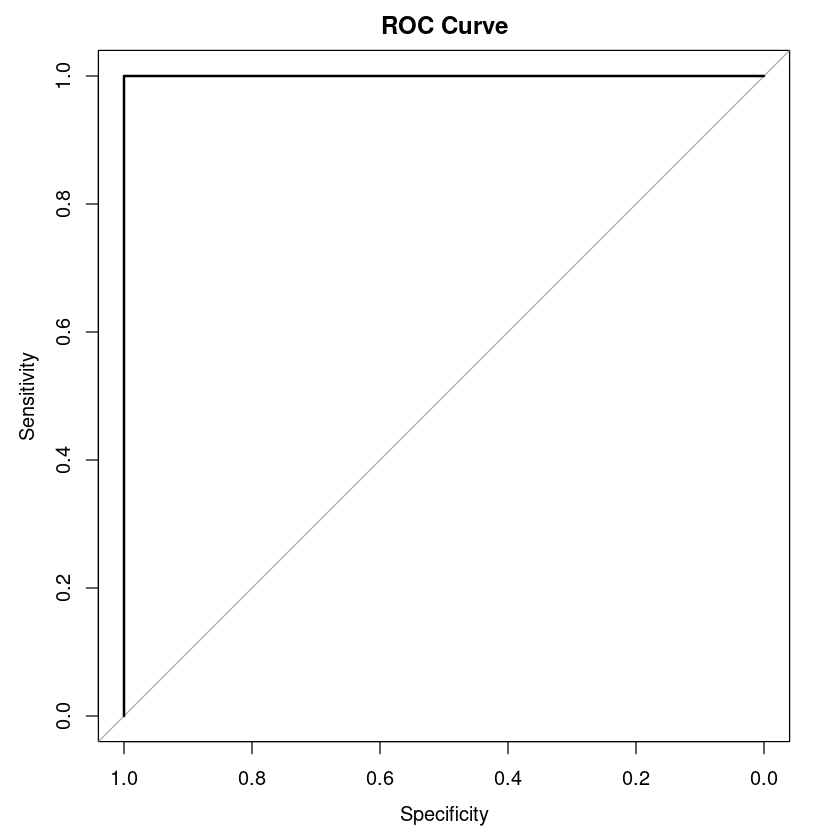

```r
roc.obj = roc(response = iSetosa, predictor = setosa.prob, levels = c("notsetosa","setosa"))
plot(roc.obj, main = "ROC Curve")
auc(roc.obj)
```

```r
library(caret)

set.seed(121)


# Define training control
ctrl = trainControl(method = "cv", number = 10)

# Fit Naive Bayes model using caret (Gaussian NB)
fit.nb = train(Species ~ .,
               data = train.dat,
               method = "nb",          # from klaR package
               trControl = ctrl)

# Display the trained model and best tuning parameters
fit.nb

# Predict on test set
pred.class = predict(fit.nb, test.dat)
confusionMatrix(pred.class, test.dat$Species)
```

[output not shown]

[output not shown]

```r
library(caret)
# The naive Bayes model created using the training data
 nb.fit = naive_bayes(Species ~ ., data = iris, ntree = Num_Trees)
 #nb.fit


# making predictions
 yhat.class = predict(nb.fit, newdata = iris)
 #yhat.class

#confusing matrix
confusion.mat = confusionMatrix(yhat.class, iris$Species)
confusion.mat
```

```
Confusion Matrix and Statistics

            Reference
Prediction   setosa versicolor virginica
  setosa         50          0         0
  versicolor      0         47         3
  virginica       0          3        47

Overall Statistics

               Accuracy : 0.96
                 95% CI : (0.915, 0.9852)
    No Information Rate : 0.3333
    P-Value [Acc > NIR] : < 2.2e-16

                  Kappa : 0.94

 Mcnemar's Test P-Value : NA

Statistics by Class:

                     Class: setosa Class: versicolor Class: virginica
Sensitivity                 1.0000            0.9400           0.9400
Specificity                 1.0000            0.9700           0.9700
Pos Pred Value              1.0000            0.9400           0.9400
Neg Pred Value              1.0000            0.9700           0.9700
Prevalence                  0.3333            0.3333           0.3333
Detection Rate              0.3333            0.3133           0.3133
Detection Prevalence        0.3333            0.3333           0.3333
Balanced Accuracy           1.0000            0.9550           0.9550
```

```r
# Use lasso or ridge regression for classfication

#To build a predictive model via Lasso (elastic net) to predict " Species" using other features in iris data.

# R caret train function for classfication: elsatic net
fit.train <- train(
  Species ~., data = iris, method = "glmnet",
  trControl = trainControl("cv",
                           number = 10,
                           classProbs = TRUE,
                           savePredictions = TRUE),
 #  alpha=model$bestTune$alpha,
 #  lambda=model$bestTune$lambda,
  tuneLength = 10,
  metric="Accuracy"
)

yhat = predict(fit.train, iris)
confusion.mat = confusionMatrix(yhat, iris$Species)

confusion.mat
```

```
Confusion Matrix and Statistics

            Reference
Prediction   setosa versicolor virginica
  setosa         50          0         0
  versicolor      0         47         1
  virginica       0          3        49

Overall Statistics

               Accuracy : 0.9733
                 95% CI : (0.9331, 0.9927)
    No Information Rate : 0.3333
    P-Value [Acc > NIR] : < 2.2e-16

                  Kappa : 0.96

 Mcnemar's Test P-Value : NA

Statistics by Class:

                     Class: setosa Class: versicolor Class: virginica
Sensitivity                 1.0000            0.9400           0.9800
Specificity                 1.0000            0.9900           0.9700
Pos Pred Value              1.0000            0.9792           0.9423
Neg Pred Value              1.0000            0.9706           0.9898
Prevalence                  0.3333            0.3333           0.3333
Detection Rate              0.3333            0.3133           0.3267
Detection Prevalence        0.3333            0.3200           0.3467
Balanced Accuracy           1.0000            0.9650           0.9750
```